# Keras API Project Exercise

## The Data

We will be using a subset of the LendingClub DataSet obtained from Kaggle: https://www.kaggle.com/wordsforthewise/lending-club

## NOTE: Do not download the full zip from the link! We provide a special version of this file that has some extra feature engineering for you to do. You won't be able to follow along with the original file!

LendingClub is a US peer-to-peer lending company, headquartered in San Francisco, California.[3] It was the first peer-to-peer lender to register its offerings as securities with the Securities and Exchange Commission (SEC), and to offer loan trading on a secondary market. LendingClub is the world's largest peer-to-peer lending platform.

### Our Goal

Given historical data on loans given out with information on whether or not the borrower defaulted (charge-off), can we build a model thatcan predict wether or nor a borrower will pay back their loan? This way in the future when we get a new potential customer we can assess whether or not they are likely to pay back the loan. Keep in mind classification metrics when evaluating the performance of your model!

The "loan_status" column contains our label.

### Data Overview

There are many LendingClub data sets on Kaggle. Here is the information on this particular data set:

|  | LoanStatNew | Description |
| --- | --- | --- |
| 0 | loan_amnt | The listed amount of the loan applied for by the borrower. If at some point in time, the credit department reduces the loan amount, then it will be reflected in this value. |
| 1 | term | The number of payments on the loan. Values are in months and can be either 36 or 60. |
| 2 | int_rate | Interest Rate on the loan |
| 3 | installment | The monthly payment owed by the borrower if the loan originates. |
| 4 | grade | LC assigned loan grade |
| 5 | sub_grade | LC assigned loan subgrade |
| 6 | emp_title | The job title supplied by the Borrower when applying for the loan.* |
| 7 | emp_length | Employment length in years. Possible values are between 0 and 10 where 0 means less than one year and 10 means ten or more years. |
| 8 | home_ownership | The home ownership status provided by the borrower during registration or obtained from the credit report. Our values are: RENT, OWN, MORTGAGE, OTHER |
| 9 | annual_inc | The self-reported annual income provided by the borrower during registration. |
| 10 | verification_status | Indicates if income was verified by LC, not verified, or if the income source was verified |
| 11 | issue_d | The month which the loan was funded |
| 12 | loan_status | Current status of the loan |
| 13 | purpose | A category provided by the borrower for the loan request. |
| 14 | title | The loan title provided by the borrower |
| 15 | zip_code | The first 3 numbers of the zip code provided by the borrower in the loan application. |
| 16 | addr_state | The state provided by the borrower in the loan application |
| 17 | dti | A ratio calculated using the borrower’s total monthly debt payments on the total debt obligations, excluding mortgage and the requested LC loan, divided by the borrower’s self-reported monthly income. |
| 18 | earliest_cr_line | The month the borrower's earliest reported credit line was opened |
| 19 | open_acc | The number of open credit lines in the borrower's credit file. |
| 20 | pub_rec | Number of derogatory public records |
| 21 | revol_bal | Total credit revolving balance |
| 22 | revol_util | Revolving line utilization rate, or the amount of credit the borrower is using relative to all available revolving credit. |
| 23 | total_acc | The total number of credit lines currently in the borrower's credit file |
| 24 | initial_list_status | The initial listing status of the loan. Possible values are – W, F |
| 25 | application_type | Indicates whether the loan is an individual application or a joint application with two co-borrowers |
| 26 | mort_acc | Number of mortgage accounts. |
| 27 | pub_rec_bankruptcies | Number of public record bankruptcies |

## Starter Code

#### Note: We also provide feature information on the data as a .csv file for easy lookup throughout the notebook:

```python
import pandas as pd
```

```python
data_info = pd.read_csv('inp_files/lending_club_info.csv',index_col='LoanStatNew')
```

```python
data_info.head()
```

| LoanStatNew | Description |
| --- | --- |
| loan_amnt | The listed amount of the loan applied for by t... |
| term | The number of payments on the loan. Values are... |
| int_rate | Interest Rate on the loan |
| installment | The monthly payment owed by the borrower if th... |
| grade | LC assigned loan grade |

```python
print(data_info.loc['revol_util']['Description'])
```

```
Revolving line utilization rate, or the amount of credit the borrower is using relative to all available revolving credit.
```

```python
def feat_info(col_name):
    print(data_info.loc[col_name]['Description'])
```

```python
feat_info('mort_acc')
```

```
Number of mortgage accounts.
```

## Loading the data and other imports

```python
import pandas as pd
import numpy as np
import matplotlib.pyplot as plt
import seaborn as sns

# might be needed depending on your version of Jupyter
#%matplotlib inline
```

```python
df = pd.read_csv('inp_files/lending_club_loan_two.csv')
df.head()
```

|  | loan_amnt | term | int_rate | installment | grade | sub_grade | emp_title | emp_length | home_ownership | annual_inc | ... | open_acc | pub_rec | revol_bal | revol_util | total_acc | initial_list_status | application_type | mort_acc | pub_rec_bankruptcies | address |
| --- | --- | --- | --- | --- | --- | --- | --- | --- | --- | --- | --- | --- | --- | --- | --- | --- | --- | --- | --- | --- | --- |
| 0 | 10000.0 | 36 months | 11.44 | 329.48 | B | B4 | Marketing | 10+ years | RENT | 117000.0 | ... | 16.0 | 0.0 | 36369.0 | 41.8 | 25.0 | w | INDIVIDUAL | 0.0 | 0.0 | 0174 Michelle Gateway\nMendozaberg, OK 22690 |
| 1 | 8000.0 | 36 months | 11.99 | 265.68 | B | B5 | Credit analyst | 4 years | MORTGAGE | 65000.0 | ... | 17.0 | 0.0 | 20131.0 | 53.3 | 27.0 | f | INDIVIDUAL | 3.0 | 0.0 | 1076 Carney Fort Apt. 347\nLoganmouth, SD 05113 |
| 2 | 15600.0 | 36 months | 10.49 | 506.97 | B | B3 | Statistician | < 1 year | RENT | 43057.0 | ... | 13.0 | 0.0 | 11987.0 | 92.2 | 26.0 | f | INDIVIDUAL | 0.0 | 0.0 | 87025 Mark Dale Apt. 269\nNew Sabrina, WV 05113 |
| 3 | 7200.0 | 36 months | 6.49 | 220.65 | A | A2 | Client Advocate | 6 years | RENT | 54000.0 | ... | 6.0 | 0.0 | 5472.0 | 21.5 | 13.0 | f | INDIVIDUAL | 0.0 | 0.0 | 823 Reid Ford\nDelacruzside, MA 00813 |
| 4 | 24375.0 | 60 months | 17.27 | 609.33 | C | C5 | Destiny Management Inc. | 9 years | MORTGAGE | 55000.0 | ... | 13.0 | 0.0 | 24584.0 | 69.8 | 43.0 | f | INDIVIDUAL | 1.0 | 0.0 | 679 Luna Roads\nGreggshire, VA 11650 |

5 rows × 27 columns

```python
df.info()
```

```
<class 'pandas.core.frame.DataFrame'>
RangeIndex: 396030 entries, 0 to 396029
Data columns (total 27 columns):
 #   Column                Non-Null Count   Dtype
---  ------                --------------   -----
 0   loan_amnt             396030 non-null  float64
 1   term                  396030 non-null  object
 2   int_rate              396030 non-null  float64
 3   installment           396030 non-null  float64
 4   grade                 396030 non-null  object
 5   sub_grade             396030 non-null  object
 6   emp_title             373103 non-null  object
 7   emp_length            377729 non-null  object
 8   home_ownership        396030 non-null  object
 9   annual_inc            396030 non-null  float64
```

[output cut: 19 more lines]

# Project Tasks

**Complete the tasks below! Keep in mind is usually more than one way to complete the task! Enjoy**

# Section 1: Exploratory Data Analysis

**OVERALL GOAL: Get an understanding for which variables are important, view summary statistics, and visualize the data**

**TASK: Since we will be attempting to predict loan_status, create a countplot as shown below.**

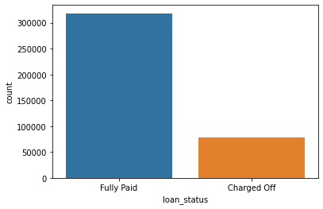

```python
sns.countplot(data=df,x='loan_status')
plt.show()
# ne balansuota klasė, taigi accuracy bus geras, bet tikrosios metrikos
# kuriomis pasiklausim yra precision ir recall (F1)
```

**TASK: Create a histogram of the loan_amnt column.**

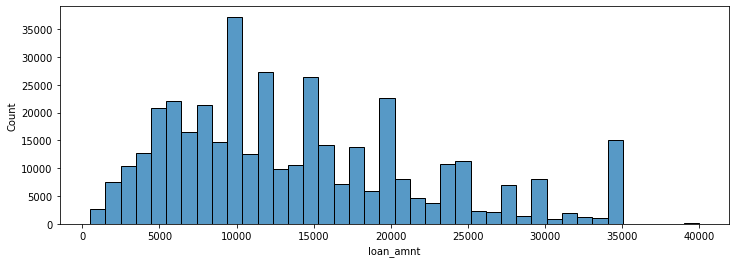

```python
plt.figure(figsize=(12,4))
sns.histplot(data=df,x='loan_amnt',bins=40)
#df['loan_amnt'].plot(kind='hist',bins=70)
plt.show()
# tsg matom, kokios sumos yra dažnos skolinantis (apvalūs, grąžūs skaičiai)
```

**TASK: Let's explore correlation between the continuous feature variables. Calculate the correlation between all continuous numeric variables using .corr() method.**

```python
df.corr()
```

|  | loan_amnt | int_rate | installment | annual_inc | dti | open_acc | pub_rec | revol_bal | revol_util | total_acc | mort_acc | pub_rec_bankruptcies |
| --- | --- | --- | --- | --- | --- | --- | --- | --- | --- | --- | --- | --- |
| loan_amnt | 1.000000 | 0.168921 | 0.953929 | 0.336887 | 0.016636 | 0.198556 | -0.077779 | 0.328320 | 0.099911 | 0.223886 | 0.222315 | -0.106539 |
| int_rate | 0.168921 | 1.000000 | 0.162758 | -0.056771 | 0.079038 | 0.011649 | 0.060986 | -0.011280 | 0.293659 | -0.036404 | -0.082583 | 0.057450 |
| installment | 0.953929 | 0.162758 | 1.000000 | 0.330381 | 0.015786 | 0.188973 | -0.067892 | 0.316455 | 0.123915 | 0.202430 | 0.193694 | -0.098628 |
| annual_inc | 0.336887 | -0.056771 | 0.330381 | 1.000000 | -0.081685 | 0.136150 | -0.013720 | 0.299773 | 0.027871 | 0.193023 | 0.236320 | -0.050162 |
| dti | 0.016636 | 0.079038 | 0.015786 | -0.081685 | 1.000000 | 0.136181 | -0.017639 | 0.063571 | 0.088375 | 0.102128 | -0.025439 | -0.014558 |
| open_acc | 0.198556 | 0.011649 | 0.188973 | 0.136150 | 0.136181 | 1.000000 | -0.018392 | 0.221192 | -0.131420 | 0.680728 | 0.109205 | -0.027732 |
| pub_rec | -0.077779 | 0.060986 | -0.067892 | -0.013720 | -0.017639 | -0.018392 | 1.000000 | -0.101664 | -0.075910 | 0.019723 | 0.011552 | 0.699408 |
| revol_bal | 0.328320 | -0.011280 | 0.316455 | 0.299773 | 0.063571 | 0.221192 | -0.101664 | 1.000000 | 0.226346 | 0.191616 | 0.194925 | -0.124532 |
| revol_util | 0.099911 | 0.293659 | 0.123915 | 0.027871 | 0.088375 | -0.131420 | -0.075910 | 0.226346 | 1.000000 | -0.104273 | 0.007514 | -0.086751 |
| total_acc | 0.223886 | -0.036404 | 0.202430 | 0.193023 | 0.102128 | 0.680728 | 0.019723 | 0.191616 | -0.104273 | 1.000000 | 0.381072 | 0.042035 |
| mort_acc | 0.222315 | -0.082583 | 0.193694 | 0.236320 | -0.025439 | 0.109205 | 0.011552 | 0.194925 | 0.007514 | 0.381072 | 1.000000 | 0.027239 |
| pub_rec_bankruptcies | -0.106539 | 0.057450 | -0.098628 | -0.050162 | -0.014558 | -0.027732 | 0.699408 | -0.124532 | -0.086751 | 0.042035 | 0.027239 | 1.000000 |

**TASK: Visualize this using a heatmap. Depending on your version of matplotlib, you may need to manually adjust the heatmap.**

- [Heatmap info](https://seaborn.pydata.org/generated/seaborn.heatmap.html#seaborn.heatmap)
- [Help with resizing](https://stackoverflow.com/questions/56942670/matplotlib-seaborn-first-and-last-row-cut-in-half-of-heatmap-plot)

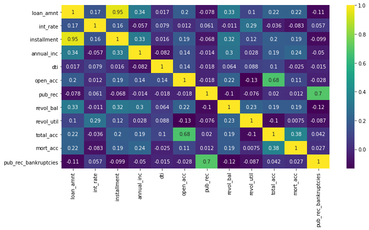

```python
plt.figure(figsize=(12,6))
sns.heatmap(data=df.corr(),annot=True,cmap='viridis')
plt.show()
```

**TASK: You should have noticed almost perfect correlation with the "installment" feature. Explore this feature further. Print out their descriptions and perform a scatterplot between them. Does this relationship make sense to you? Do you think there is duplicate information here?**

```python
feat_info('installment') # key word 'if'
```

```
The monthly payment owed by the borrower if the loan originates.
```

```python
feat_info('loan_amnt')
```

```
The listed amount of the loan applied for by the borrower. If at some point in time, the credit department reduces the loan amount, then it will be reflected in this value.
```

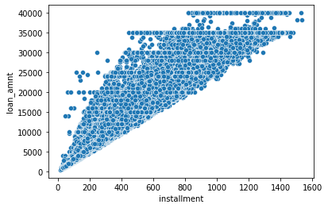

```python
sns.scatterplot(data=df,x='installment',y='loan_amnt')
plt.show()
# kadangi taip gerai koreliuoja ir pagal aprašymus matosi, kad tai duplikacija mūsų spėjamos klasės.
# negerai turėti stulpelį, kuris taip gerai koreliuoja/apibūdina tai ką bandom atspėti.
# tikriausiai installment yra paskaičiuojamas iš loan_amnt, pagal tos kompanijos funkciją, kas reiškia
# kad jie per daug priklauso/susiję viens nuo kito
```

**TASK: Create a boxplot showing the relationship between the loan_status and the Loan Amount.**

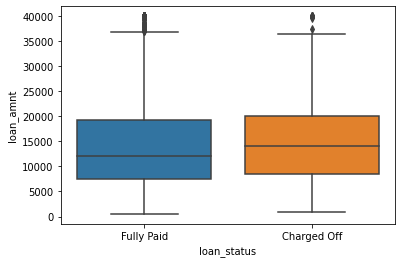

```python
# boxplotas realiai padaro groupby pagal x ir suskaičiuoja count ant y stulpelio + dar papildomą stat. info
sns.boxplot(data=df,x='loan_status', y='loan_amnt')
plt.show()
# loan_amnt nėra labai geras loan_staus prediktorius, nes vienodi pasiskristymai ar negrąžino/grąžino
# negrąžino vos vos aukščiau, kas reiškia, kad didesnes paskolas sunkiau grąžinti.
```

**TASK: Calculate the summary statistics for the loan amount, grouped by the loan_status.**

```python
df.groupby('loan_status')['loan_amnt'].describe()
```

| loan_status | count | mean | std | min | 25% | 50% | 75% | max |
| --- | --- | --- | --- | --- | --- | --- | --- | --- |
| Charged Off | 77673.0 | 15126.300967 | 8505.090557 | 1000.0 | 8525.0 | 14000.0 | 20000.0 | 40000.0 |
| Fully Paid | 318357.0 | 13866.878771 | 8302.319699 | 500.0 | 7500.0 | 12000.0 | 19225.0 | 40000.0 |

**TASK: Let's explore the Grade and SubGrade columns that LendingClub attributes to the loans. What are the unique possible grades and subgrades?**

```python
df['grade'].unique()
```

```
array(['B', 'A', 'C', 'E', 'D', 'F', 'G'], dtype=object)
```

```python
df['sub_grade'].unique()
```

```
array(['B4', 'B5', 'B3', 'A2', 'C5', 'C3', 'A1', 'B2', 'C1', 'A5', 'E4',
       'A4', 'A3', 'D1', 'C2', 'B1', 'D3', 'D5', 'D2', 'E1', 'E2', 'E5',
       'F4', 'E3', 'D4', 'G1', 'F5', 'G2', 'C4', 'F1', 'F3', 'G5', 'G4',
       'F2', 'G3'], dtype=object)
```

**TASK: Create a countplot per grade. Set the hue to the loan_status label.**

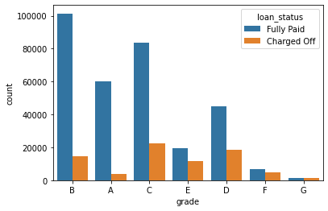

```python
sns.countplot(data=df,x='grade',hue='loan_status')
plt.show()
# pagal laon_status ratio, klientai įvertinami pažymiais, A - geriausias, G - blogiausias
```

**TASK: Display a count plot per subgrade. You may need to resize for this plot and [reorder](https://seaborn.pydata.org/generated/seaborn.countplot.html#seaborn.countplot) the x axis. Feel free to edit the color palette. Explore both all loans made per subgrade as well being separated based on the loan_status. After creating this plot, go ahead and create a similar plot, but set hue="loan_status"**

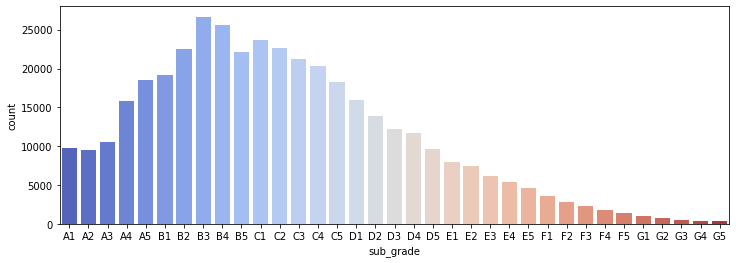

```python
plt.figure(figsize=(12,4))
sns.countplot(x=df['sub_grade'].sort_values(),palette='coolwarm')
plt.show()
```

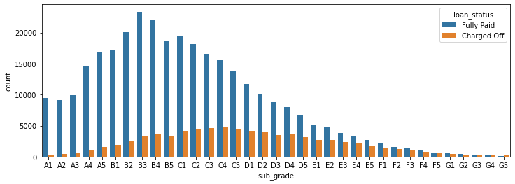

```python
plt.figure(figsize=(12,4))
sns.countplot(x=df['sub_grade'].sort_values(),hue=df['loan_status'])
plt.show()
```

**TASK: It looks like F and G subgrades don't get paid back that often. Isloate those and recreate the countplot just for those subgrades.**

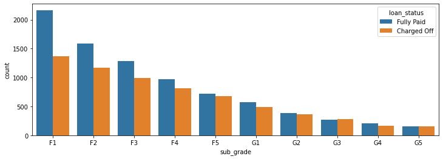

```python
FG_grades = df[(df['sub_grade'].str.startswith('F')) | (df['sub_grade']
                                                        .str.startswith('G'))]['sub_grade'].sort_values()
# galima buvo pagal 'grade' stulpelį atfiltruot
plt.figure(figsize=(12,4))
sns.countplot(x=FG_grades,hue=df['loan_status'])
plt.show()
```

**TASK: Create a new column called 'loan_repaid' which will contain a 1 if the loan status was "Fully Paid" and a 0 if it was "Charged Off".**

```python
# galima dar buvo su .map ir paduot python dict
df['loan_repaid'] = df['loan_status'].apply(lambda col: 1 if col == 'Fully Paid' else 0)
df[['loan_repaid','loan_status']]
```

|  | loan_repaid | loan_status |
| --- | --- | --- |
| 0 | 1 | Fully Paid |
| 1 | 1 | Fully Paid |
| 2 | 1 | Fully Paid |
| 3 | 1 | Fully Paid |
| 4 | 0 | Charged Off |
| ... | ... | ... |
| 396025 | 1 | Fully Paid |
| 396026 | 1 | Fully Paid |
| 396027 | 1 | Fully Paid |
| 396028 | 1 | Fully Paid |
| 396029 | 1 | Fully Paid |

396030 rows × 2 columns

**CHALLENGE TASK: (Note this is hard, but can be done in one line!) Create a bar plot showing the correlation of the numeric features to the new loan_repaid column. [Helpful Link](https://pandas.pydata.org/pandas-docs/stable/reference/api/pandas.DataFrame.plot.bar.html)**

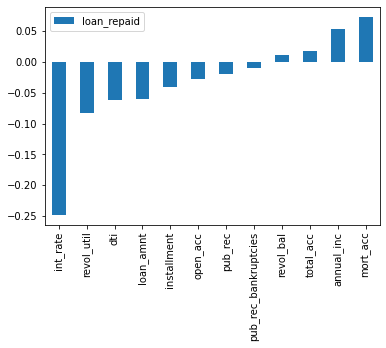

```python
#prob nebūtina į df paversti
pd.DataFrame(df.corr()['loan_repaid'][:-1].sort_values()).plot(kind='bar')
plt.show()
```

# Section 2: Data PreProcessing

**Section Goals: Remove or fill any missing data. Remove unnecessary or repetitive features. Convert categorical string features to dummy variables.**

```python
df.head()
```

|  | loan_amnt | term | int_rate | installment | grade | sub_grade | emp_title | emp_length | home_ownership | annual_inc | ... | pub_rec | revol_bal | revol_util | total_acc | initial_list_status | application_type | mort_acc | pub_rec_bankruptcies | address | loan_repaid |
| --- | --- | --- | --- | --- | --- | --- | --- | --- | --- | --- | --- | --- | --- | --- | --- | --- | --- | --- | --- | --- | --- |
| 0 | 10000.0 | 36 months | 11.44 | 329.48 | B | B4 | Marketing | 10+ years | RENT | 117000.0 | ... | 0.0 | 36369.0 | 41.8 | 25.0 | w | INDIVIDUAL | 0.0 | 0.0 | 0174 Michelle Gateway\nMendozaberg, OK 22690 | 1 |
| 1 | 8000.0 | 36 months | 11.99 | 265.68 | B | B5 | Credit analyst | 4 years | MORTGAGE | 65000.0 | ... | 0.0 | 20131.0 | 53.3 | 27.0 | f | INDIVIDUAL | 3.0 | 0.0 | 1076 Carney Fort Apt. 347\nLoganmouth, SD 05113 | 1 |
| 2 | 15600.0 | 36 months | 10.49 | 506.97 | B | B3 | Statistician | < 1 year | RENT | 43057.0 | ... | 0.0 | 11987.0 | 92.2 | 26.0 | f | INDIVIDUAL | 0.0 | 0.0 | 87025 Mark Dale Apt. 269\nNew Sabrina, WV 05113 | 1 |
| 3 | 7200.0 | 36 months | 6.49 | 220.65 | A | A2 | Client Advocate | 6 years | RENT | 54000.0 | ... | 0.0 | 5472.0 | 21.5 | 13.0 | f | INDIVIDUAL | 0.0 | 0.0 | 823 Reid Ford\nDelacruzside, MA 00813 | 1 |
| 4 | 24375.0 | 60 months | 17.27 | 609.33 | C | C5 | Destiny Management Inc. | 9 years | MORTGAGE | 55000.0 | ... | 0.0 | 24584.0 | 69.8 | 43.0 | f | INDIVIDUAL | 1.0 | 0.0 | 679 Luna Roads\nGreggshire, VA 11650 | 0 |

5 rows × 28 columns

# Missing Data

**Let's explore this missing data columns. We use a variety of factors to decide whether or not they would be useful, to see if we should keep, discard, or fill in the missing data.**

Realiai, žiūrim kiekvieną stulpelį kuriame yra missing data ir aiškinamęs kam jis skirtas ir kodėl ten missing. Dažniausiai nebus žinoma kodėl, tai reik išsiaiškinti ar tas stulpelis/bruožas svarbus mums prognozuojant klasę. Jeigu nesvarbus, tai išmetam visą stulpelį, jeigu lb mažai missing data, galim eilutes išmest. Jeigu svarbus, tai reikia sugalvoti kaip jį fillinti (galbūt pagal kitus stulpelius jeigu yra susijusių) arba transformuoti (pvz. į kitokio tipo) kur nebebūtų missing data.

**TASK: What is the length of the dataframe?**

```python
len(df)
```

```
396030
```

**TASK: Create a Series that displays the total count of missing values per column.**

```python
df.isnull().sum()
```

```
loan_amnt                   0
term                        0
int_rate                    0
installment                 0
grade                       0
sub_grade                   0
emp_title               22927
emp_length              18301
home_ownership              0
annual_inc                  0
verification_status         0
issue_d                     0
loan_status                 0
purpose                     0
title                    1755
dti                         0
earliest_cr_line            0
open_acc                    0
pub_rec                     0
revol_bal                   0
revol_util                276
total_acc                   0
initial_list_status         0
application_type            0
mort_acc                37795
pub_rec_bankruptcies      535
address                     0
loan_repaid                 0
dtype: int64
```

**TASK: Convert this Series to be in term of percentage of the total DataFrame**

```python
100 * df.isnull().sum() / len(df)
```

```
loan_amnt               0.000000
term                    0.000000
int_rate                0.000000
installment             0.000000
grade                   0.000000
sub_grade               0.000000
emp_title               5.789208
emp_length              4.621115
home_ownership          0.000000
annual_inc              0.000000
verification_status     0.000000
issue_d                 0.000000
loan_status             0.000000
purpose                 0.000000
title                   0.443148
dti                     0.000000
earliest_cr_line        0.000000
open_acc                0.000000
pub_rec                 0.000000
revol_bal               0.000000
revol_util              0.069692
total_acc               0.000000
initial_list_status     0.000000
application_type        0.000000
mort_acc                9.543469
pub_rec_bankruptcies    0.135091
address                 0.000000
loan_repaid             0.000000
dtype: float64
```

**TASK: Let's examine emp_title and emp_length to see whether it will be okay to drop them. Print out their feature information using the feat_info() function from the top of this notebook.**

```python
feat_info('emp_title')
```

```
The job title supplied by the Borrower when applying for the loan.*
```

```python
feat_info('emp_length')
```

```
Employment length in years. Possible values are between 0 and 10 where 0 means less than one year and 10 means ten or more years.
```

**TASK: How many unique employment job titles are there?**

```python
len(df['emp_title'].unique())
```

```
173106
```

```python
df['emp_title'].value_counts()
```

```
Teacher                                     4389
Manager                                     4250
Registered Nurse                            1856
RN                                          1846
Supervisor                                  1830
                                            ...
Military U.S. Marines                          1
costumer engineer                              1
Cream of the Crop  AG Service, INC             1
Youth and Family Alternatives                  1
Director of Gvt Outreach & Communication       1
Name: emp_title, Length: 173105, dtype: int64
```

**TASK: Realistically there are too many unique job titles to try to convert this to a dummy variable feature. Let's remove that emp_title column.**

```python
# kadangi naudosim neural nets, kur inputai privalo būti skaičiai, tai visus kategorinius bruožus reiks
# paversti dummies, o čia jų tiek daug, kad bruožų žiauriai padaugės (+ 170K naujų boolean stulpelių)
# ta info tikriausiai nėra labai svarbi, nes daug unikaliu, tik po 1 žmogų turinčių darbų pavadinimų
# aišku galima daug darbo įdėti ir paversti į kitokias kategorijas, pagal daug uždirbančius
# vidtiniškai, mažai ar kaip nors kitaip.
df = df.drop('emp_title',axis=1)
```

**TASK: Create a count plot of the emp_length feature column. Challenge: Sort the order of the values.**

```python
# df['emp_length'].sort_values().unique() - galima ir taip pasiimti
sorted(df['emp_length'].dropna().unique())
```

```
['1 year',
 '10+ years',
 '2 years',
 '3 years',
 '4 years',
 '5 years',
 '6 years',
 '7 years',
 '8 years',
 '9 years',
 '< 1 year']
```

```python
# tuomet pačiam rankom pasidaryti masyvą pagal kurį sortins seaborn
emp_length_order = [
    '< 1 year',
    '1 year',
    '2 years',
    '3 years',
    '4 years',
    '5 years',
    '6 years',
    '7 years',
    '8 years',
    '9 years',
    '10+ years']
```

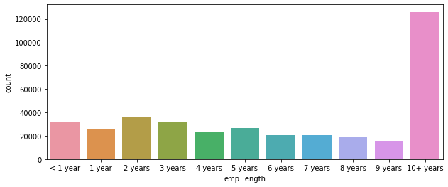

```python
plt.figure(figsize=(10,4))
sns.countplot(data=df,x='emp_length',order=emp_length_order)
plt.show()
```

**TASK: Plot out the countplot with a hue separating Fully Paid vs Charged Off**

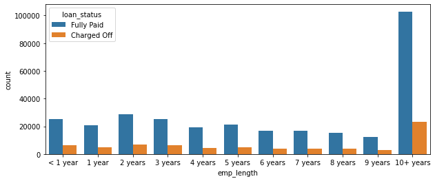

```python
# pažiūrim ant kiek svarbus šitas bruožas prediktinant loan_status klasę
plt.figure(figsize=(10,4))
sns.countplot(data=df,x='emp_length',order=emp_length_order,hue='loan_status')
plt.show()
# ratio fully paid vs charged off (negrazino) yra vienodas žmonėms pagal tai kiek laiko jie dirba
# kitaip tariant nėra svarbus bruožas, nes nuo to kiek dirbai nepriklauso ar grąžinsi daugiau ar mažiau paskolų
# tačiau taip vienareikšmiškai negalim pasakyt, reiktų patikrinti procentą žmonių kurie negražino kiekvienai
# emp_length reikšmei ir pažiūrėt ar kuris nors labiau kitoks negu kiti.
```

**CHALLENGE TASK: This still doesn't really inform us if there is a strong relationship between employment length and being charged off, what we want is the percentage of charge offs per category. Essentially informing us what percent of people per employment category didn't pay back their loan. There are a multitude of ways to create this Series. Once you've created it, see if visualize it with a [bar plot](https://pandas.pydata.org/pandas-docs/version/0.23.4/generated/pandas.DataFrame.plot.html). This may be tricky, refer to solutions if you get stuck on creating this Series.**

```python
df.groupby('emp_length')['loan_status']\
.apply(lambda col: col.value_counts()['Charged Off'] / len(col))
```

```
emp_length
1 year       0.199135
10+ years    0.184186
2 years      0.193262
3 years      0.195231
4 years      0.192385
5 years      0.192187
6 years      0.189194
7 years      0.194774
8 years      0.199760
9 years      0.200470
< 1 year     0.206872
Name: loan_status, dtype: float64
```

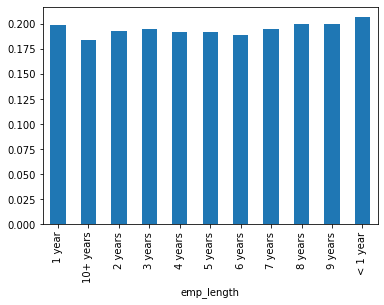

```python
df.groupby('emp_length')['loan_status']\
.apply(lambda col: col.value_counts()['Charged Off'] / len(col))\
.plot(kind='bar')
plt.show()
# visi praktiškai vienodi, 10+ tik mažesnis negu kiti, reikškia daugiau dirbi = mažiau skolų turėsi
# bet ne daug mažesnis, taigi šitas bruožas nėra svarbus, mažai priklauso nuo klasės kurią bandom prognozuoti
# todėl galim išmesti stulpelį
```

**TASK: Charge off rates are extremely similar across all employment lengths. Go ahead and drop the emp_length column.**

```python
df = df.drop('emp_length', axis=1)
```

**TASK: Revisit the DataFrame to see what feature columns still have missing data.**

```python
df.isnull().sum()
```

```
loan_amnt                   0
term                        0
int_rate                    0
installment                 0
grade                       0
sub_grade                   0
home_ownership              0
annual_inc                  0
verification_status         0
issue_d                     0
loan_status                 0
purpose                     0
title                    1755
dti                         0
earliest_cr_line            0
open_acc                    0
pub_rec                     0
revol_bal                   0
revol_util                276
total_acc                   0
initial_list_status         0
application_type            0
mort_acc                37795
pub_rec_bankruptcies      535
address                     0
loan_repaid                 0
dtype: int64
```

**TASK: Review the title column vs the purpose column. Is this repeated information?**

```python
df['purpose'].head(10)
```

```
0              vacation
1    debt_consolidation
2           credit_card
3           credit_card
4           credit_card
5    debt_consolidation
6      home_improvement
7           credit_card
8    debt_consolidation
9    debt_consolidation
Name: purpose, dtype: object
```

```python
df['title'].head(10)
```

```
0                   Vacation
1         Debt consolidation
2    Credit card refinancing
3    Credit card refinancing
4      Credit Card Refinance
5         Debt consolidation
6           Home improvement
7       No More Credit Cards
8         Debt consolidation
9         Debt Consolidation
Name: title, dtype: object
```

**TASK: The title column is simply a string subcategory/description of the purpose column. Go ahead and drop the title column.**

```python
feat_info('title')
```

```
The loan title provided by the borrower
```

```python
feat_info('purpose')
```

```
A category provided by the borrower for the loan request.
```

```python
# title stulpelis tsg poaibis purpose stulpelio, tai jį galima išmest
df = df.drop('title', axis=1)
```

**NOTE: This is one of the hardest parts of the project! Refer to the solutions video if you need guidance, feel free to fill or drop the missing values of the mort_acc however you see fit! Here we're going with a very specific approach.**

**TASK: Find out what the mort_acc feature represents**

```python
feat_info('mort_acc')
# nežinom kodėl kai kurie skolinimo kompanijos klientai neturi šių duomenų
# galėtume paversti į kategorinį stulpelį ir nan padaryt kaip atskirą 'unknown' kategoriją
# arba galim tsg tą stulpelį išmesti, tai nebūtų big deal
# aišku eilutes išmesti kur missing to stulpelio būtų ne kažką, nes 10% duomenų panaikintume

# dar vienas variantas yra patikrinti ar yra stulpelis kuris koreliuoja su šiuo bruožu ir pagal jį
# bandyti kaip nors protingai fillint reikšmes.
```

```
Number of mortgage accounts.
```

**TASK: Create a value_counts of the mort_acc column.**

```python
df['mort_acc'].value_counts()
```

```
0.0     139777
1.0      60416
2.0      49948
3.0      38049
4.0      27887
5.0      18194
6.0      11069
7.0       6052
8.0       3121
9.0       1656
10.0       865
11.0       479
12.0       264
13.0       146
14.0       107
15.0        61
16.0        37
17.0        22
18.0        18
19.0        15
20.0        13
24.0        10
22.0         7
21.0         4
25.0         4
27.0         3
23.0         2
32.0         2
26.0         2
31.0         2
30.0         1
28.0         1
34.0         1
Name: mort_acc, dtype: int64
```

**TASK: There are many ways we could deal with this missing data. We could attempt to build a simple model to fill it in, such as a linear model, we could just fill it in based on the mean of the other columns, or you could even bin the columns into categories and then set NaN as its own category. There is no 100% correct approach! Let's review the other columsn to see which most highly correlates to mort_acc**

```python
df.corr()['mort_acc'].sort_values()
# total_acc - yra kiek iš viso žmogus turi skirtingų paskyrų/kontraktų toje kompanijoje
# morg_acc - kiek tų paskyrų/kontraktų yra susiję su būsto paskola

# ne aukšta koreliacija, reiškia ne duplikatas, bet kaip ir logiška, kad pagal bendrą acc skaičių galim
# užpildyti būsto acc skaičių
```

```
int_rate               -0.082583
dti                    -0.025439
revol_util              0.007514
pub_rec                 0.011552
pub_rec_bankruptcies    0.027239
loan_repaid             0.073111
open_acc                0.109205
installment             0.193694
revol_bal               0.194925
loan_amnt               0.222315
annual_inc              0.236320
total_acc               0.381072
mort_acc                1.000000
Name: mort_acc, dtype: float64
```

**TASK: Looks like the total_acc feature correlates with the mort_acc , this makes sense! Let's try this fillna() approach. We will group the dataframe by the total_acc and calculate the mean value for the mort_acc per total_acc entry. To get the result below:**

```python
df.groupby('total_acc')['mort_acc'].mean()
```

```
total_acc
2.0      0.000000
3.0      0.052023
4.0      0.066743
5.0      0.103289
6.0      0.151293
           ...
124.0    1.000000
129.0    1.000000
135.0    3.000000
150.0    2.000000
151.0    0.000000
Name: mort_acc, Length: 118, dtype: float64
```

**CHALLENGE TASK: Let's fill in the missing mort_acc values based on their total_acc value. If the mort_acc is missing, then we will fill in that missing value with the mean value corresponding to its total_acc value from the Series we created above. This involves using an .apply() method with two columns. Check out the link below for more info, or review the solutions video/notebook.**

[Helpful Link](https://stackoverflow.com/questions/13331698/how-to-apply-a-function-to-two-columns-of-pandas-dataframe)

```python
df.groupby('total_acc')['mort_acc'].transform(lambda val: val.fillna(val.mean()))
```

```
0         0.000000
1         3.000000
2         0.000000
3         0.000000
4         1.000000
            ...
396025    0.000000
396026    1.000000
396027    0.000000
396028    5.000000
396029    1.358013
Name: mort_acc, Length: 396030, dtype: float64
```

```python
df['mort_acc'] = df.groupby('total_acc')['mort_acc'].transform(lambda val: val.fillna(val.mean()))
```

```python
df.isnull().sum()
```

```
loan_amnt                 0
term                      0
int_rate                  0
installment               0
grade                     0
sub_grade                 0
home_ownership            0
annual_inc                0
verification_status       0
issue_d                   0
loan_status               0
purpose                   0
dti                       0
earliest_cr_line          0
open_acc                  0
pub_rec                   0
revol_bal                 0
revol_util              276
total_acc                 0
initial_list_status       0
application_type          0
mort_acc                  0
pub_rec_bankruptcies    535
address                   0
loan_repaid               0
dtype: int64
```

**TASK: revol_util and the pub_rec_bankruptcies have missing data points, but they account for less than 0.5% of the total data. Go ahead and remove the rows that are missing those values in those columns with dropna().**

```python
feat_info('revol_util')
```

```
Revolving line utilization rate, or the amount of credit the borrower is using relative to all available revolving credit.
```

```python
feat_info('pub_rec_bankruptcies')
```

```
Number of public record bankruptcies
```

```python
df = df.dropna()
```

```python
df.isnull().sum()
```

```
loan_amnt               0
term                    0
int_rate                0
installment             0
grade                   0
sub_grade               0
home_ownership          0
annual_inc              0
verification_status     0
issue_d                 0
loan_status             0
purpose                 0
dti                     0
earliest_cr_line        0
open_acc                0
pub_rec                 0
revol_bal               0
revol_util              0
total_acc               0
initial_list_status     0
application_type        0
mort_acc                0
pub_rec_bankruptcies    0
address                 0
loan_repaid             0
dtype: int64
```